# Project 4 - Andrew Susanto

## Building Decision Tree

```python
#building model for decision tree
dTree = DecisionTreeClassifier(criterion = 'gini', random_state=1)
dTree.fit(x_train, y_train)
```

```
DecisionTreeClassifier(random_state=1)
```

```python
#checking accuracy of decision tree
print("Accuracy on training set : ",dTree.score(x_train, y_train))
print("Accuracy on test set : ",dTree.score(x_test, y_test))
```

```
Accuracy on training set :  1.0
Accuracy on test set :  0.9777777777777777
```

The accuracy of the model is high, but there seems to be a hint of overfitting as the accuracy on test set is lower than that of training set.

```python
#Checking number of positives
y.sum(axis = 0)
```

```
480
```

```python
#function to create confusion matrix
def make_confusion_matrix(model,y_actual,labels=[1, 0]):
    '''
    model : classifier to predict values of X
    y_actual : ground truth

    '''
    y_predict = model.predict(x_test)
    cm=metrics.confusion_matrix( y_actual, y_predict, labels=[0, 1])
    df_cm = pd.DataFrame(cm, index = [i for i in ["Actual - No","Actual - Yes"]],
                  columns = [i for i in ['Predicted - No','Predicted - Yes']])
    group_counts = ["{0:0.0f}".format(value) for value in
                cm.flatten()]
    group_percentages = ["{0:.2%}".format(value) for value in
                         cm.flatten()/np.sum(cm)]
    labels = [f"{v1}\n{v2}" for v1, v2 in
              zip(group_counts,group_percentages)]
    labels = np.asarray(labels).reshape(2,2)
    plt.figure(figsize = (10,7))
    sns.heatmap(df_cm, annot=labels,fmt='')
    plt.ylabel('True label')
    plt.xlabel('Predicted label')
```

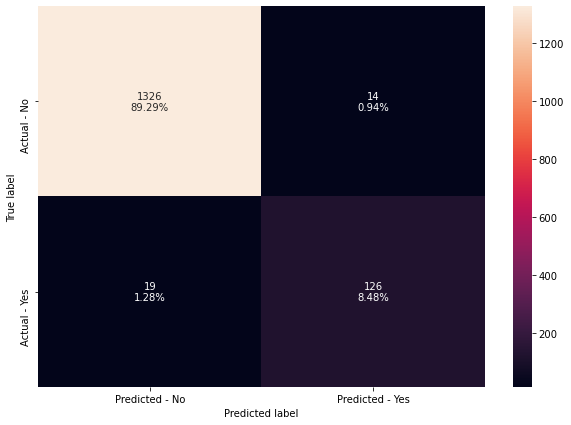

```python
#showing confusion matrix of the decision tree model
make_confusion_matrix(dTree,y_test)
```

```python
#showing recall value of the decision tree model
get_recall_score(dTree)
```

```
Recall on training set :  1.0
Recall on test set :  0.8689655172413793
```

```python
#showing precision and F1 score

y_predict1 = dTree.predict(x_test)
print("Precision: ",precision_score(y_test, y_predict1))
print("F1 score: ",f1_score(y_test, y_predict1))
```

```
Precision:  0.9
F1 score:  0.8842105263157896
```

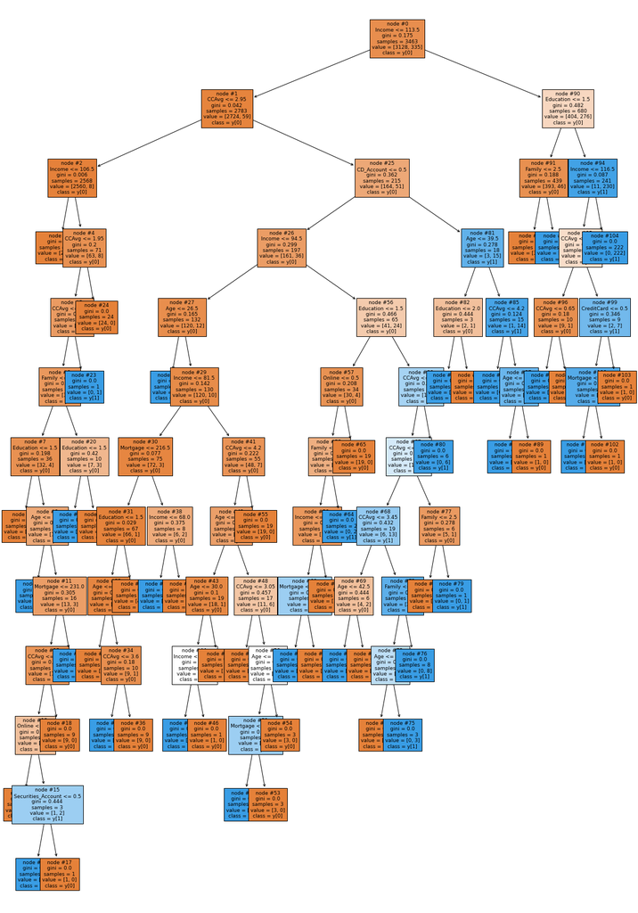

```python
#plotting the decision tree

plt.figure(figsize=(20,30))
tree.plot_tree(dTree,feature_names=list(x.columns),filled=True,fontsize=9,node_ids=True,class_names=True)
plt.show()
```

It can be seen that there are too much branches on the tree, and this model could lead to overfitting.

```python
#text report version of the decision tree

print(tree.export_text(dTree,feature_names=list(x.columns),show_weights=True))
```

```
|--- Income <= 113.50
|   |--- CCAvg <= 2.95
|   |   |--- Income <= 106.50
|   |   |   |--- weights: [2497.00, 0.00] class: 0
|   |   |--- Income >  106.50
|   |   |   |--- CCAvg <= 1.95
|   |   |   |   |--- CCAvg <= 1.85
|   |   |   |   |   |--- Family <= 3.50
|   |   |   |   |   |   |--- Education <= 1.50
|   |   |   |   |   |   |   |--- weights: [19.00, 0.00] class: 0
|   |   |   |   |   |   |--- Education >  1.50
|   |   |   |   |   |   |   |--- Age <= 29.50
|   |   |   |   |   |   |   |   |--- weights: [0.00, 1.00] class: 1
|   |   |   |   |   |   |   |--- Age >  29.50
|   |   |   |   |   |   |   |   |--- Mortgage <= 231.00
|   |   |   |   |   |   |   |   |   |--- CCAvg <= 1.15
|   |   |   |   |   |   |   |   |   |   |--- Online <= 0.50
|   |   |   |   |   |   |   |   |   |   |   |--- weights: [3.00, 0.00] class: 0
|   |   |   |   |   |   |   |   |   |   |--- Online >  0.50
|   |   |   |   |   |   |   |   |   |   |   |--- truncated branch of depth 2
|   |   |   |   |   |   |   |   |   |--- CCAvg >  1.15
|   |   |   |   |   |   |   |   |   |   |--- weights: [9.00, 0.00] class: 0
|   |   |   |   |   |   |   |   |--- Mortgage >  231.00
|   |   |   |   |   |   |   |   |   |--- weights: [0.00, 1.00] class: 1
|   |   |   |   |   |--- Family >  3.50
|   |   |   |   |   |   |--- Education <= 1.50
|   |   |   |   |   |   |   |--- weights: [0.00, 3.00] class: 1
|   |   |   |   |   |   |--- Education >  1.50
|   |   |   |   |   |   |   |--- weights: [7.00, 0.00] class: 0
|   |   |   |   |--- CCAvg >  1.85
|   |   |   |   |   |--- weights: [0.00, 1.00] class: 1
|   |   |   |--- CCAvg >  1.95
|   |   |   |   |--- weights: [24.00, 0.00] class: 0
|   |--- CCAvg >  2.95
|   |   |--- CD_Account <= 0.50
|   |   |   |--- Income <= 94.50
|   |   |   |   |--- Age <= 26.50
|   |   |   |   |   |--- weights: [0.00, 2.00] class: 1
|   |   |   |   |--- Age >  26.50
|   |   |   |   |   |--- Income <= 81.50
```

[output cut: 99 more lines]

```
|   |   |   |--- CCAvg <= 2.15
|   |   |   |   |--- CCAvg <= 0.65
|   |   |   |   |   |--- weights: [0.00, 1.00] class: 1
|   |   |   |   |--- CCAvg >  0.65
|   |   |   |   |   |--- weights: [9.00, 0.00] class: 0
|   |   |   |--- CCAvg >  2.15
|   |   |   |   |--- CreditCard <= 0.50
|   |   |   |   |   |--- Mortgage <= 141.50
|   |   |   |   |   |   |--- weights: [0.00, 7.00] class: 1
|   |   |   |   |   |--- Mortgage >  141.50
|   |   |   |   |   |   |--- weights: [1.00, 0.00] class: 0
|   |   |   |   |--- CreditCard >  0.50
|   |   |   |   |   |--- weights: [1.00, 0.00] class: 0
|   |   |--- Income >  116.50
|   |   |   |--- weights: [0.00, 222.00] class: 1
```

```python
#finding the importance of features in the decision tree (Gini importance)
print (pd.DataFrame(dTree.feature_importances_, columns = ["Imp"], index = x_train.columns).sort_values(by = 'Imp', ascending = False))
```

```
                         Imp
Education           0.396891
Income              0.311479
Family              0.145495
CCAvg               0.069847
Age                 0.029255
CD_Account          0.023071
Mortgage            0.015337
Online              0.004173
CreditCard          0.002249
Securities_Account  0.002203
```

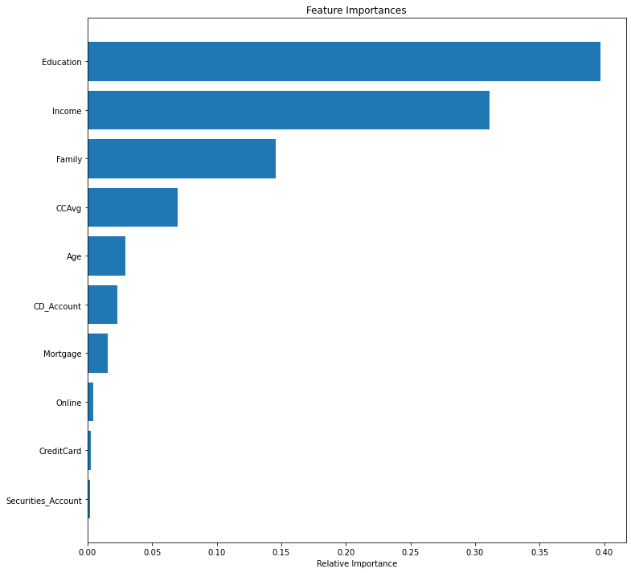

```python
#plotting of feature importances
importances = dTree.feature_importances_
indices = np.argsort(importances)

plt.figure(figsize=(12,12))
plt.title('Feature Importances')
plt.barh(range(len(indices)), importances[indices], align='center')
plt.yticks(range(len(indices)), [list(x.columns)[i] for i in indices])
plt.xlabel('Relative Importance')
plt.show()
```

The important feature for the tree here are education, followed by income and then family.

There is a possible hint on overfitting based on the recall value, as the recall value on the training set is significantly higher than the recall on test set. The decision tree itself also looks too complex. We need to get rid of overfitting by applying pruning techniques to the decision tree, whether it's pre-pruning or post-pruning.

## Building Decision Tree with Pre-Pruning (Max Depth = 3)

We will try to limit the number of branches of the decision tree, so let's try limiting the maximum depth of the tree to 3.

```python
#creation of model with max depth of 3

dTree1 = DecisionTreeClassifier(criterion = 'gini',max_depth=3,random_state=1)
dTree1.fit(x_train, y_train)
```

```
DecisionTreeClassifier(max_depth=3, random_state=1)
```

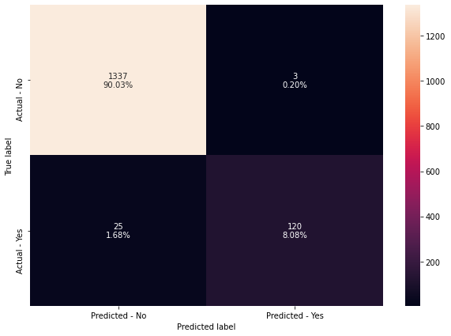

```python
#confusion matrix of the updated decision tree
make_confusion_matrix(dTree1, y_test)
```

```python
#printing accuracy values
print("Accuracy on training set : ",dTree1.score(x_train, y_train))
print("Accuracy on test set : ",dTree1.score(x_test, y_test))

#printing recall values
get_recall_score(dTree1)

#printing precision and F1 score
y_predict2 = dTree1.predict(x_test)
print("Precision: ",precision_score(y_test, y_predict2))
print("F1 score: ",f1_score(y_test, y_predict2))
```

```
Accuracy on training set :  0.9841178169217442
Accuracy on test set :  0.9811447811447811
Recall on training set :  0.844776119402985
Recall on test set :  0.8275862068965517
Precision:  0.975609756097561
F1 score:  0.8955223880597015
```

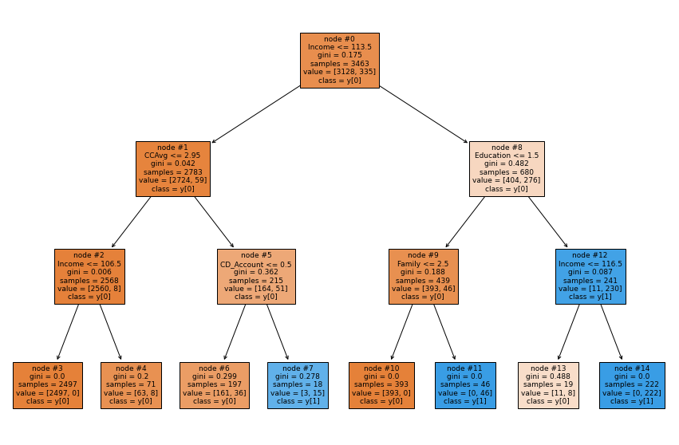

```python
#plotting decision tree
plt.figure(figsize=(15,10))

tree.plot_tree(dTree1,feature_names=list(x.columns),filled=True,fontsize=9,node_ids=True,class_names=True)
plt.show()
```

```python
#text report version of the decision tree

print(tree.export_text(dTree1,feature_names=list(x.columns),show_weights=True))
```

```
|--- Income <= 113.50
|   |--- CCAvg <= 2.95
|   |   |--- Income <= 106.50
|   |   |   |--- weights: [2497.00, 0.00] class: 0
|   |   |--- Income >  106.50
|   |   |   |--- weights: [63.00, 8.00] class: 0
|   |--- CCAvg >  2.95
|   |   |--- CD_Account <= 0.50
|   |   |   |--- weights: [161.00, 36.00] class: 0
|   |   |--- CD_Account >  0.50
|   |   |   |--- weights: [3.00, 15.00] class: 1
|--- Income >  113.50
|   |--- Education <= 1.50
|   |   |--- Family <= 2.50
|   |   |   |--- weights: [393.00, 0.00] class: 0
|   |   |--- Family >  2.50
|   |   |   |--- weights: [0.00, 46.00] class: 1
|   |--- Education >  1.50
|   |   |--- Income <= 116.50
|   |   |   |--- weights: [11.00, 8.00] class: 0
|   |   |--- Income >  116.50
|   |   |   |--- weights: [0.00, 222.00] class: 1
```

```python
#finding the importance of features in the decision tree (Gini importance)
print (pd.DataFrame(dTree1.feature_importances_, columns = ["Imp"], index = x_train.columns).sort_values(by = 'Imp', ascending = False))
```

```
                         Imp
Education           0.433683
Income              0.338340
Family              0.159032
CCAvg               0.041985
CD_Account          0.026960
Age                 0.000000
Mortgage            0.000000
Securities_Account  0.000000
Online              0.000000
CreditCard          0.000000
```

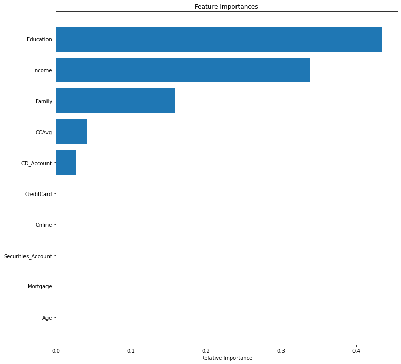

```python
#plotting of feature importances
importances = dTree1.feature_importances_
indices = np.argsort(importances)

plt.figure(figsize=(12,12))
plt.title('Feature Importances')
plt.barh(range(len(indices)), importances[indices], align='center')
plt.yticks(range(len(indices)), [list(x.columns)[i] for i in indices])
plt.xlabel('Relative Importance')
plt.show()
```

Similar to the original decision tree model, the top three important features are education, followed by income and family. the accuracy and recall between training and testing data does not seem to differ much, and hence the model does not seem to overfit. Let's continue to build the decision tree using hyperparameter tuning to find the best value of metrics.

## Building Decision Tree with Hyperparameter Tuning

```python
#importing of gridsearchCV for usage of hyperparameter tuning
from sklearn.model_selection import GridSearchCV
```

```python
#choosing the type of classifier.
estimator = DecisionTreeClassifier(random_state=1,class_weight = {0:.1,1:.9})

#Grid of parameters to choose from
parameters = {
            'max_depth': np.arange(1,10),
            'criterion': ['entropy','gini'],
            'splitter': ['best','random'],
            'min_impurity_decrease': [0.000001,0.00001,0.0001],
            'max_features': ['log2','sqrt']
             }

#Type of scoring used to compare parameter combinations
scorer = metrics.make_scorer(metrics.recall_score)

#running the grid search
grid_obj = GridSearchCV(estimator, parameters, scoring=scorer,cv=5)
grid_obj = grid_obj.fit(x_train, y_train)

#setting the clf to the best combination of parameters
estimator = grid_obj.best_estimator_

#fitting the best algorithm to the data.
estimator.fit(x_train, y_train)
```

```
DecisionTreeClassifier(class_weight={0: 0.1, 1: 0.9}, criterion='entropy',
                       max_depth=4, max_features='log2',
                       min_impurity_decrease=1e-06, random_state=1)
```

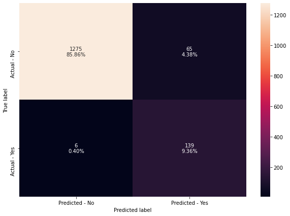

```python
#confusion matrix of the model
make_confusion_matrix(estimator, y_test)
```

```python
# Accuracy on train and test
print("Accuracy on training set : ",estimator.score(x_train, y_train))
print("Accuracy on test set : ",estimator.score(x_test, y_test))
# Recall on train and test
get_recall_score(estimator)

y_predict3 = estimator.predict(x_test)
print("Precision: ",precision_score(y_test, y_predict3))
print("F1 score: ",f1_score(y_test, y_predict3))
```

```
Accuracy on training set :  0.9393589373375686
Accuracy on test set :  0.9521885521885521
Recall on training set :  0.9761194029850746
Recall on test set :  0.9586206896551724
Precision:  0.6813725490196079
F1 score:  0.7965616045845272
```

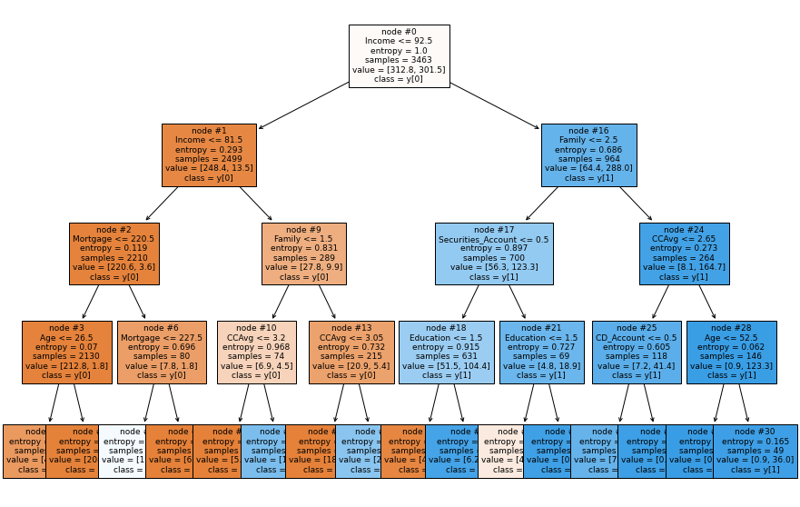

```python
#plotting tree model
plt.figure(figsize=(15,10))

tree.plot_tree(estimator,feature_names=list(x.columns),filled=True,fontsize=9,node_ids=True,class_names=True)
plt.show()
```

```python
#text report version of the decision tree

print(tree.export_text(estimator,feature_names=list(x.columns),show_weights=True))
```

```
|--- Income <= 92.50
|   |--- Income <= 81.50
|   |   |--- Mortgage <= 220.50
|   |   |   |--- Age <= 26.50
|   |   |   |   |--- weights: [4.70, 0.90] class: 0
|   |   |   |--- Age >  26.50
|   |   |   |   |--- weights: [208.10, 0.90] class: 0
|   |   |--- Mortgage >  220.50
|   |   |   |--- Mortgage <= 227.50
|   |   |   |   |--- weights: [1.70, 1.80] class: 1
|   |   |   |--- Mortgage >  227.50
|   |   |   |   |--- weights: [6.10, 0.00] class: 0
|   |--- Income >  81.50
|   |   |--- Family <= 1.50
|   |   |   |--- CCAvg <= 3.20
|   |   |   |   |--- weights: [5.40, 0.00] class: 0
|   |   |   |--- CCAvg >  3.20
|   |   |   |   |--- weights: [1.50, 4.50] class: 1
|   |   |--- Family >  1.50
|   |   |   |--- CCAvg <= 3.05
|   |   |   |   |--- weights: [18.70, 0.00] class: 0
|   |   |   |--- CCAvg >  3.05
|   |   |   |   |--- weights: [2.20, 5.40] class: 1
|--- Income >  92.50
|   |--- Family <= 2.50
|   |   |--- Securities_Account <= 0.50
|   |   |   |--- Education <= 1.50
|   |   |   |   |--- weights: [45.30, 1.80] class: 0
|   |   |   |--- Education >  1.50
|   |   |   |   |--- weights: [6.20, 102.60] class: 1
|   |   |--- Securities_Account >  0.50
|   |   |   |--- Education <= 1.50
|   |   |   |   |--- weights: [4.30, 3.60] class: 0
|   |   |   |--- Education >  1.50
|   |   |   |   |--- weights: [0.50, 15.30] class: 1
|   |--- Family >  2.50
|   |   |--- CCAvg <= 2.65
|   |   |   |--- CD_Account <= 0.50
|   |   |   |   |--- weights: [7.00, 30.60] class: 1
|   |   |   |--- CD_Account >  0.50
|   |   |   |   |--- weights: [0.20, 10.80] class: 1
|   |   |--- CCAvg >  2.65
|   |   |   |--- Age <= 52.50
|   |   |   |   |--- weights: [0.00, 87.30] class: 1
|   |   |   |--- Age >  52.50
|   |   |   |   |--- weights: [0.90, 36.00] class: 1
```

```python
#finding the importance of features in the decision tree (Gini importance)
print (pd.DataFrame(estimator.feature_importances_, columns = ["Imp"], index = x_train.columns).sort_values(by = 'Imp', ascending = False))
```

```
                         Imp
Income              0.632403
Education           0.208204
Family              0.069355
CCAvg               0.058115
Mortgage            0.016311
Age                 0.009367
CD_Account          0.003818
Securities_Account  0.002427
Online              0.000000
CreditCard          0.000000
```

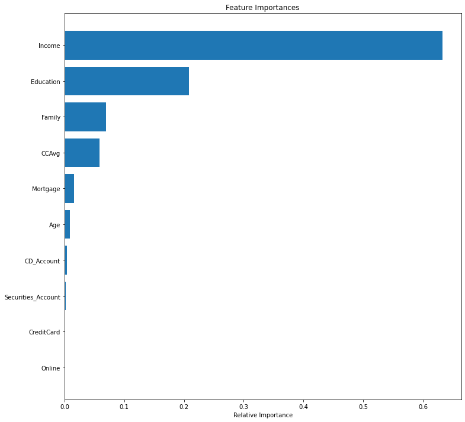

```python
#plotting of feature importances
importances = estimator.feature_importances_
indices = np.argsort(importances)

plt.figure(figsize=(12,12))
plt.title('Feature Importances')
plt.barh(range(len(indices)), importances[indices], align='center')
plt.yticks(range(len(indices)), [list(x.columns)[i] for i in indices])
plt.xlabel('Relative Importance')
plt.show()
```

The recall from the model is further improved from the previous models. It can be noted that the most important feature is income (differs from the previous model), followed by education and then family.

## Building Decision Tree with Post-Pruning

```python
#modelling post-pruned decision tree

clf = DecisionTreeClassifier(random_state=1,class_weight = {0:0.1,1:0.9})
path = clf.cost_complexity_pruning_path(x_train, y_train)
ccp_alphas, impurities = path.ccp_alphas, path.impurities
```

```python
pd.DataFrame(path)
```

|  | ccp_alphas | impurities |
| --- | --- | --- |
| 0 | 0.000000e+00 | -1.048956e-16 |
| 1 | 3.795325e-19 | -1.045160e-16 |
| 2 | 5.060434e-19 | -1.040100e-16 |
| 3 | 5.421893e-19 | -1.034678e-16 |
| 4 | 5.964083e-19 | -1.028714e-16 |
| 5 | 6.506272e-19 | -1.022208e-16 |
| 6 | 1.301254e-18 | -1.009195e-16 |
| 7 | 1.355473e-18 | -9.956403e-17 |
| 8 | 2.927822e-18 | -9.663621e-17 |
| 9 | 2.293461e-17 | -7.370160e-17 |
| 10 | 1.597651e-16 | 8.606352e-17 |
| 11 | 1.735006e-16 | 2.595641e-16 |
| 12 | 7.785116e-15 | 8.044680e-15 |
| 13 | 1.569731e-04 | 3.139462e-04 |
| 14 | 1.592481e-04 | 6.324423e-04 |
| 15 | 1.602434e-04 | 9.529291e-04 |
| 16 | 1.611590e-04 | 1.275247e-03 |
| 17 | 2.930164e-04 | 1.568264e-03 |
| 18 | 2.930164e-04 | 1.861280e-03 |
| 19 | 3.061366e-04 | 3.085826e-03 |
| 20 | 3.106256e-04 | 3.396452e-03 |
| 21 | 3.139462e-04 | 3.710398e-03 |
| 22 | 3.149927e-04 | 4.340383e-03 |
| 23 | 3.167745e-04 | 4.657158e-03 |
| 24 | 3.919893e-04 | 5.833126e-03 |
| 25 | 4.318751e-04 | 7.992502e-03 |
| 26 | 4.357009e-04 | 9.299604e-03 |
| 27 | 4.626575e-04 | 1.022492e-02 |
| 28 | 5.367399e-04 | 1.183514e-02 |
| 29 | 5.645990e-04 | 1.239974e-02 |
| 30 | 6.330122e-04 | 1.366576e-02 |
| 31 | 8.954972e-04 | 1.456126e-02 |
| 32 | 1.095087e-03 | 1.675143e-02 |
| 33 | 1.518676e-03 | 2.282614e-02 |
| 34 | 1.541088e-03 | 2.436722e-02 |
| 35 | 2.231526e-03 | 2.659875e-02 |
| 36 | 2.257663e-03 | 3.337174e-02 |
| 37 | 2.652845e-03 | 3.602459e-02 |
| 38 | 2.803227e-03 | 3.882781e-02 |
| 39 | 3.864408e-03 | 4.269222e-02 |
| 40 | 4.062986e-03 | 4.675521e-02 |
| 41 | 4.223906e-03 | 5.097911e-02 |
| 42 | 7.346262e-03 | 6.567164e-02 |
| 43 | 1.004844e-02 | 7.572008e-02 |
| 44 | 3.071450e-02 | 1.064346e-01 |
| 45 | 5.286592e-02 | 2.121664e-01 |
| 46 | 2.876644e-01 | 4.998308e-01 |

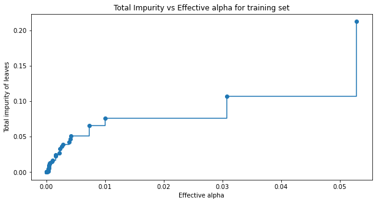

```python
#figure on total impurity vs effective alpha for training

fig, ax = plt.subplots(figsize=(10,5))
ax.plot(ccp_alphas[:-1], impurities[:-1], marker='o', drawstyle="steps-post")
ax.set_xlabel("Effective alpha")
ax.set_ylabel("Total impurity of leaves")
ax.set_title("Total Impurity vs Effective alpha for training set")
plt.show()
```

```python
clfs = []
for ccp_alpha in ccp_alphas:
    clf = DecisionTreeClassifier(random_state=1, ccp_alpha=ccp_alpha,class_weight = {0:0.1,1:0.9})
    clf.fit(x_train, y_train)
    clfs.append(clf)
print("Number of nodes in the last tree is: {} with ccp_alpha: {}".format(
      clfs[-1].tree_.node_count, ccp_alphas[-1]))
```

```
Number of nodes in the last tree is: 1 with ccp_alpha: 0.28766438315118725
```

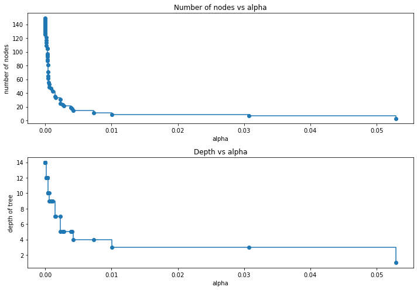

```python
clfs = clfs[:-1]
ccp_alphas = ccp_alphas[:-1]

node_counts = [clf.tree_.node_count for clf in clfs]
depth = [clf.tree_.max_depth for clf in clfs]
fig, ax = plt.subplots(2, 1,figsize=(10,7))
ax[0].plot(ccp_alphas, node_counts, marker='o', drawstyle="steps-post")
ax[0].set_xlabel("alpha")
ax[0].set_ylabel("number of nodes")
ax[0].set_title("Number of nodes vs alpha")
ax[1].plot(ccp_alphas, depth, marker='o', drawstyle="steps-post")
ax[1].set_xlabel("alpha")
ax[1].set_ylabel("depth of tree")
ax[1].set_title("Depth vs alpha")
fig.tight_layout()
```

```python
#finding recall in training data

recall_train=[]
for clf in clfs:
    pred_train3=clf.predict(x_train)
    values_train=metrics.recall_score(y_train,pred_train3)
    recall_train.append(values_train)
```

```python
#finding recall in test data

recall_test=[]
for clf in clfs:
    pred_test3=clf.predict(x_test)
    values_test=metrics.recall_score(y_test,pred_test3)
    recall_test.append(values_test)
```

```python
#training & testing scores

train_scores = [clf.score(x_train, y_train) for clf in clfs]
test_scores = [clf.score(x_test, y_test) for clf in clfs]
```

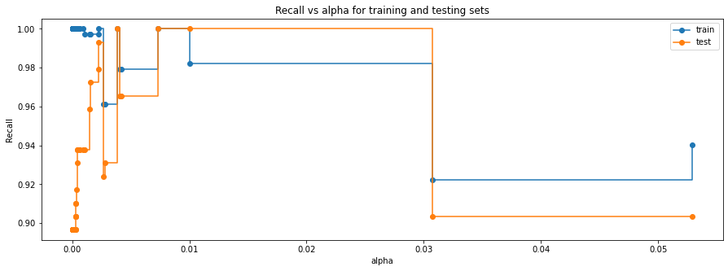

```python
#Recall vs alpha for training and testing sets

fig, ax = plt.subplots(figsize=(15,5))
ax.set_xlabel("alpha")
ax.set_ylabel("Recall")
ax.set_title("Recall vs alpha for training and testing sets")
ax.plot(ccp_alphas, recall_train, marker='o', label="train",
        drawstyle="steps-post",)
ax.plot(ccp_alphas, recall_test, marker='o', label="test",
        drawstyle="steps-post")
ax.legend()
plt.show()
```

```python
#creating the model where we get highest train and test recall
index_best_model = np.argmax(recall_test)
best_model = clfs[index_best_model]
print(best_model)
```

```
DecisionTreeClassifier(ccp_alpha=0.003864408355795341,
                       class_weight={0: 0.1, 1: 0.9}, random_state=1)
```

```python
#accuracy of post-pruning decision tree model

print('Training accuracy of best model: ',best_model.score(x_train, y_train))
print('Test accuracy of best model: ',best_model.score(x_test, y_test))
```

```
Training accuracy of best model:  0.9428241409182789
Test accuracy of best model:  0.9528619528619529
```

```python
best_model.fit(x_train, y_train)
```

```
DecisionTreeClassifier(ccp_alpha=0.003864408355795341,
                       class_weight={0: 0.1, 1: 0.9}, random_state=1)
```

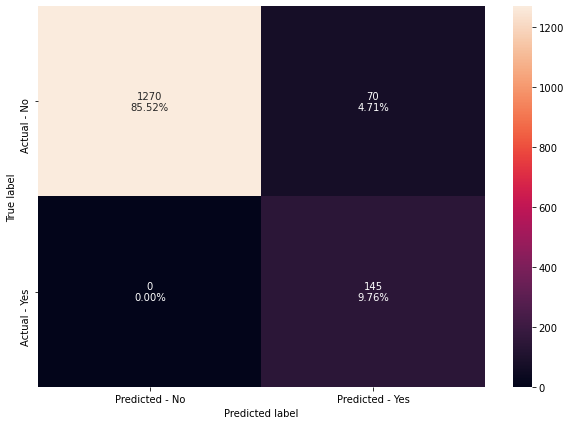

```python
#confusion matrix of post-pruning decision tree model

make_confusion_matrix(best_model,y_test)
```

```python
#recall of the model

get_recall_score(best_model)
```

```
Recall on training set :  1.0
Recall on test set :  1.0
```

```python
y_predict4 = best_model.predict(x_test)
print("Precision: ",precision_score(y_test, y_predict4))
print("F1 score: ",f1_score(y_test, y_predict4))
```

```
Precision:  0.6744186046511628
F1 score:  0.8055555555555556
```

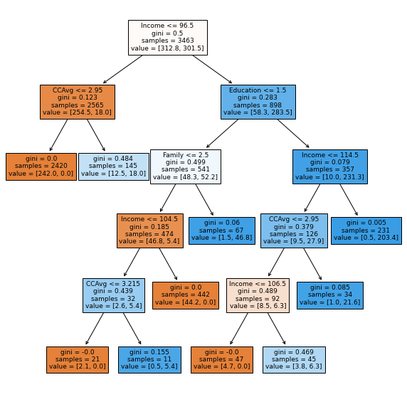

```python
#visualizing decision tree

plt.figure(figsize=(10,10))

out = tree.plot_tree(best_model,feature_names=list(x.columns),filled=True,fontsize=9,node_ids=False,class_names=None)
for o in out:
    arrow = o.arrow_patch
    if arrow is not None:
        arrow.set_edgecolor('black')
        arrow.set_linewidth(1)
plt.show()
```

```python
#text report version of the decision tree

print(tree.export_text(best_model,feature_names=list(x.columns),show_weights=True))
```

```
|--- Income <= 96.50
|   |--- CCAvg <= 2.95
|   |   |--- weights: [242.00, 0.00] class: 0
|   |--- CCAvg >  2.95
|   |   |--- weights: [12.50, 18.00] class: 1
|--- Income >  96.50
|   |--- Education <= 1.50
|   |   |--- Family <= 2.50
|   |   |   |--- Income <= 104.50
|   |   |   |   |--- CCAvg <= 3.21
|   |   |   |   |   |--- weights: [2.10, 0.00] class: 0
|   |   |   |   |--- CCAvg >  3.21
|   |   |   |   |   |--- weights: [0.50, 5.40] class: 1
|   |   |   |--- Income >  104.50
|   |   |   |   |--- weights: [44.20, 0.00] class: 0
|   |   |--- Family >  2.50
|   |   |   |--- weights: [1.50, 46.80] class: 1
|   |--- Education >  1.50
|   |   |--- Income <= 114.50
|   |   |   |--- CCAvg <= 2.95
|   |   |   |   |--- Income <= 106.50
|   |   |   |   |   |--- weights: [4.70, 0.00] class: 0
|   |   |   |   |--- Income >  106.50
|   |   |   |   |   |--- weights: [3.80, 6.30] class: 1
|   |   |   |--- CCAvg >  2.95
|   |   |   |   |--- weights: [1.00, 21.60] class: 1
|   |   |--- Income >  114.50
|   |   |   |--- weights: [0.50, 203.40] class: 1
```

```python
#finding the importance of features in the decision tree (Gini importance)
print (pd.DataFrame(best_model.feature_importances_, columns = ["Imp"], index = x_train.columns).sort_values(by = 'Imp', ascending = False))
```

```
                         Imp
Income              0.674384
Family              0.133839
Education           0.097451
CCAvg               0.094325
Age                 0.000000
Mortgage            0.000000
Securities_Account  0.000000
CD_Account          0.000000
Online              0.000000
CreditCard          0.000000
```

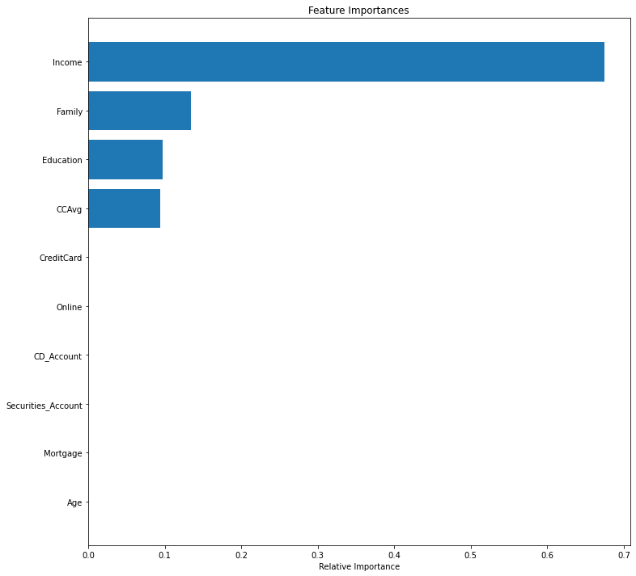

```python
#plotting of feature importances
importances = best_model.feature_importances_
indices = np.argsort(importances)

plt.figure(figsize=(12,12))
plt.title('Feature Importances')
plt.barh(range(len(indices)), importances[indices], align='center')
plt.yticks(range(len(indices)), [list(x.columns)[i] for i in indices])
plt.xlabel('Relative Importance')
plt.show()
```

Similar to the pre-pruned decision tree model with hyperparameter tuning, the most important feature of the model is income. However, the 2nd most important feature is family, and then followed by education. Let's compare the recall values of the 4 decision tree models.

## Comparison of Decision Tree Models

```python
comparison_frame = pd.DataFrame({'Model':['Initial decision tree model','Pre-pruned decision tree with max depth of 3', 'Pre-pruned decision tree with hyperparameter tuning',
                                          'Decision tree with post-pruning'], 'Train_Recall':[1,0.84,0.98,1], 'Test_Recall':[0.87,0.83,0.96,1]})
comparison_frame
```

|  | Model | Train_Recall | Test_Recall |
| --- | --- | --- | --- |
| 0 | Initial decision tree model | 1.00 | 0.87 |
| 1 | Pre-pruned decision tree with max depth of 3 | 0.84 | 0.83 |
| 2 | Pre-pruned decision tree with hyperparameter t... | 0.98 | 0.96 |
| 3 | Decision tree with post-pruning | 1.00 | 1.00 |

Hence, we can find that decision tree with post-pruning has the highest recall on test set.

## Exploratory Data Analysis on Incorrectly Predicted Data

Here, we used decision tree model with post-pruning

```python
#creating testdata dataframe
testdata = pd.concat([x_test,y_test], axis = 1)
```

```python
testdata.head()
```

|  | Age | Income | Family | CCAvg | Education | Mortgage | Securities_Account | CD_Account | Online | CreditCard | Personal_Loan |
| --- | --- | --- | --- | --- | --- | --- | --- | --- | --- | --- | --- |
| 2376 | 58 | 23 | 3 | 0.2 | 1 | 0 | 0 | 0 | 0 | 0 | 0 |
| 3641 | 59 | 74 | 4 | 2.3 | 3 | 0 | 0 | 0 | 0 | 0 | 0 |
| 3774 | 51 | 52 | 4 | 1.8 | 3 | 0 | 0 | 0 | 1 | 0 | 0 |
| 4143 | 55 | 20 | 2 | 0.3 | 1 | 0 | 0 | 0 | 1 | 0 | 0 |
| 250 | 30 | 29 | 3 | 1.0 | 2 | 117 | 0 | 0 | 0 | 0 | 0 |

```python
#creation of new column to check if the predicted result is the same as the data from testdata
#true means model predicted data matches current data
#false means the model predicted data does not match current data

testdata['actualVSmodel'] = (y_test == y_predict4)
testdata.head()
```

|  | Age | Income | Family | CCAvg | Education | Mortgage | Securities_Account | CD_Account | Online | CreditCard | Personal_Loan | actualVSmodel |
| --- | --- | --- | --- | --- | --- | --- | --- | --- | --- | --- | --- | --- |
| 2376 | 58 | 23 | 3 | 0.2 | 1 | 0 | 0 | 0 | 0 | 0 | 0 | True |
| 3641 | 59 | 74 | 4 | 2.3 | 3 | 0 | 0 | 0 | 0 | 0 | 0 | True |
| 3774 | 51 | 52 | 4 | 1.8 | 3 | 0 | 0 | 0 | 1 | 0 | 0 | True |
| 4143 | 55 | 20 | 2 | 0.3 | 1 | 0 | 0 | 0 | 1 | 0 | 0 | True |
| 250 | 30 | 29 | 3 | 1.0 | 2 | 117 | 0 | 0 | 0 | 0 | 0 | True |

```python
#counting how many data match/don't match between actual data and model predicted data
testdata['actualVSmodel'].value_counts()
```

```
True     1415
False      70
Name: actualVSmodel, dtype: int64
```

```python
testdata.info()
```

```
<class 'pandas.core.frame.DataFrame'>
Int64Index: 1485 entries, 2376 to 928
Data columns (total 12 columns):
 #   Column              Non-Null Count  Dtype
---  ------              --------------  -----
 0   Age                 1485 non-null   int64
 1   Income              1485 non-null   int64
 2   Family              1485 non-null   int64
 3   CCAvg               1485 non-null   float64
 4   Education           1485 non-null   int64
 5   Mortgage            1485 non-null   int64
 6   Securities_Account  1485 non-null   int64
 7   CD_Account          1485 non-null   int64
 8   Online              1485 non-null   int64
 9   CreditCard          1485 non-null   int64
 10  Personal_Loan       1485 non-null   int64
 11  actualVSmodel       1485 non-null   bool
dtypes: bool(1), float64(1), int64(10)
memory usage: 140.7 KB
```

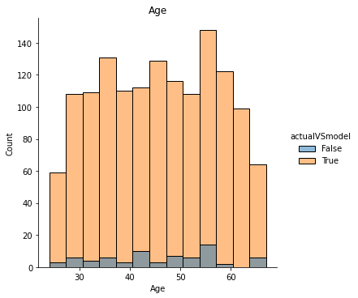

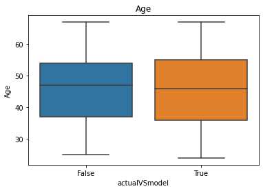

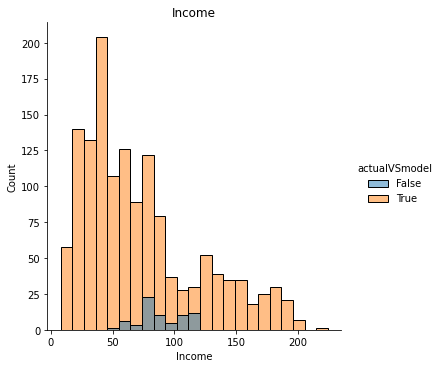

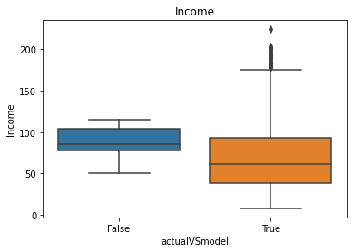

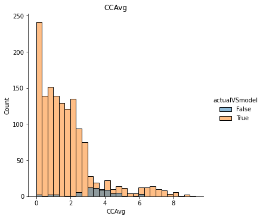

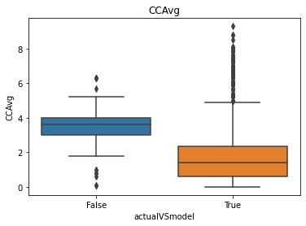

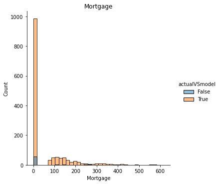

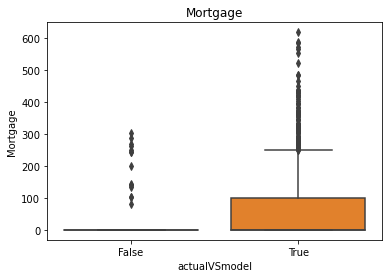

```python
#univariate analysis of continous variables

for i in ['Age','Income','CCAvg','Mortgage']:
    sns.displot(testdata, x=i, hue='actualVSmodel').set(title=i)
    plt.show()
    sns.boxplot(data=testdata, x='actualVSmodel', y=i).set(title=i)
    plt.show()
```

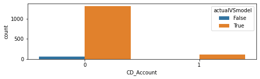

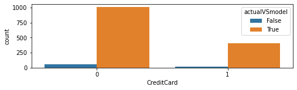

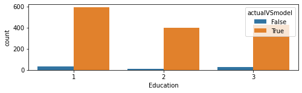

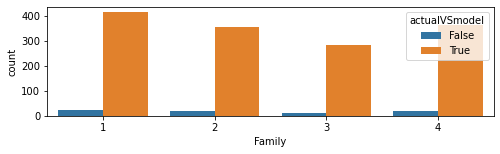

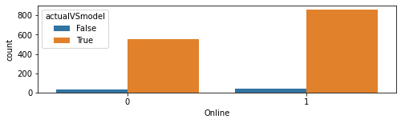

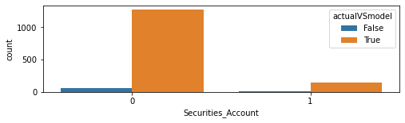

```python
#univariate analysis of categorical/dummy variables

for i in ['CD_Account','CreditCard','Education','Family','Online','Securities_Account']:
    plt.figure(figsize=(8,2))
    sns.countplot(testdata[i], hue=testdata['actualVSmodel'])
    plt.show()
```

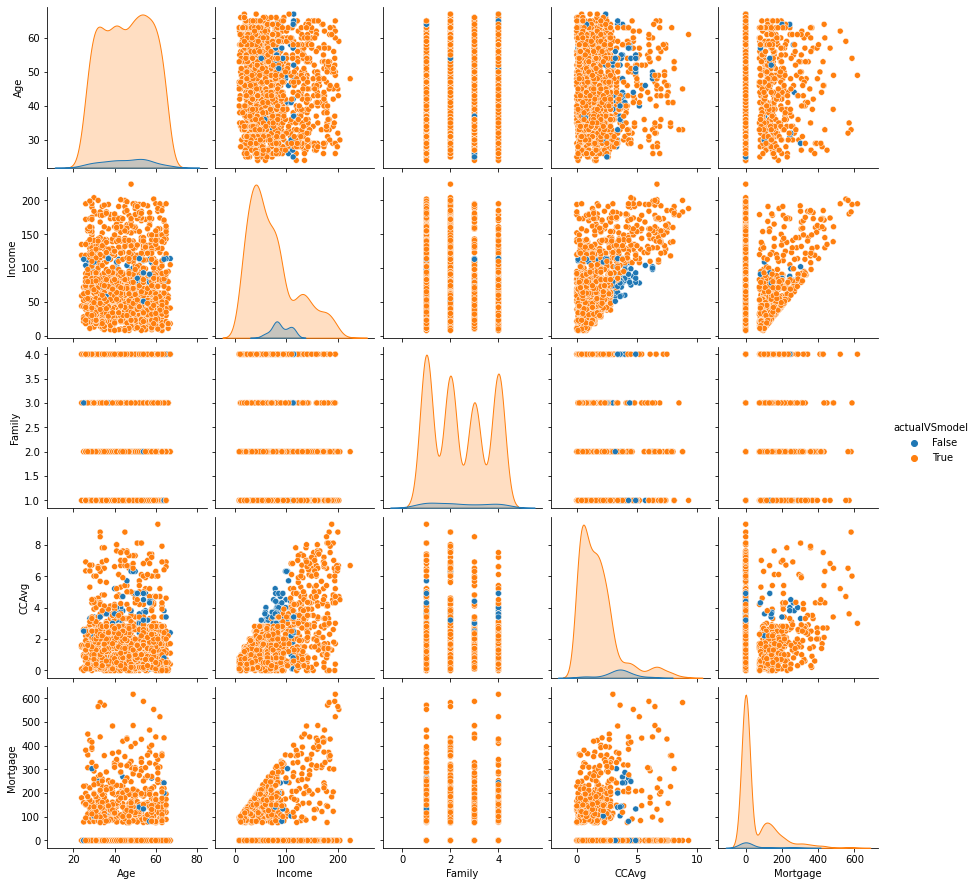

```python
#bivariate analysis of numerical variables using pairplot

sns.pairplot(testdata[['Age','Income','Family','CCAvg','Mortgage','actualVSmodel']], hue='actualVSmodel')
```

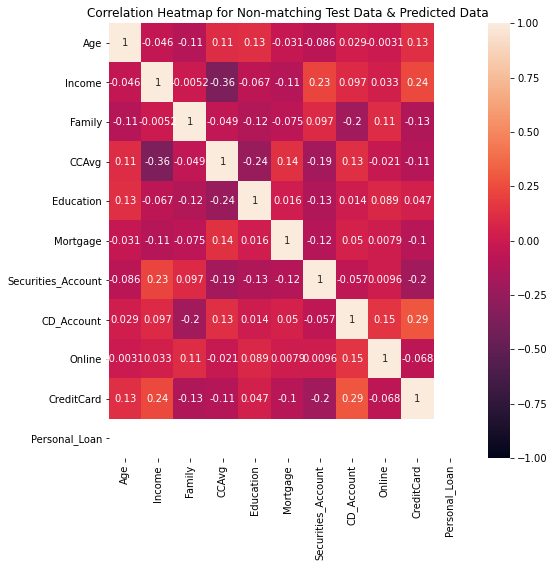

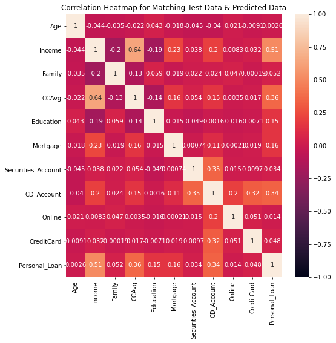

```python
#bivariate analysis using heatmap

#Heatmap for non-matching ytest & predicted data
plt.figure(figsize=(8,8))
sns.heatmap(testdata[testdata['actualVSmodel']==False].drop(['actualVSmodel'],axis=1).corr(), annot=True, vmin=-1, vmax=1).set(title='Correlation Heatmap for Non-matching Test Data & Predicted Data')
plt.show()

#Heatmap for matching ytest & predicted data
plt.figure(figsize=(8,8))
sns.heatmap(testdata[testdata['actualVSmodel']==True].drop(['actualVSmodel'],axis=1).corr(), annot=True, vmin=-1, vmax=1).set(title='Correlation Heatmap for Matching Test Data & Predicted Data')
plt.show()
plt.tight_layout()
```

From the exploratory data analysis done, it can be found that:

1. The non-matching data between y_test and model predicted result only account to 5%
2. The non-matching data between y_test and model predicted result are mostly of CCAvg around 4
3. The non-matching data between y_test and model predicted result are mostly of income around 90-100
4. The non-matching data between y_test and model predicted result are mostly of mortgage value around 0
5. There does not seem to be any significant multicolinearity as shown in the heatmap.

## Actionable Insights & Recommendations

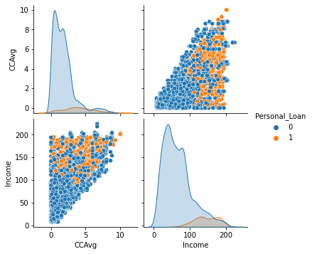

```python
#creating a pairplot

sns.pairplot(df[['CCAvg','Income','Personal_Loan']], hue='Personal_Loan')
```

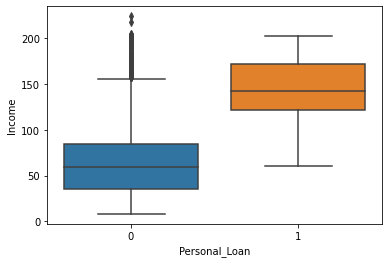

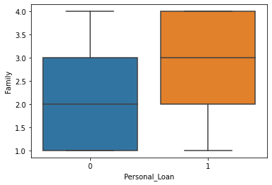

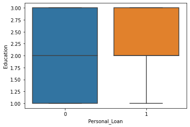

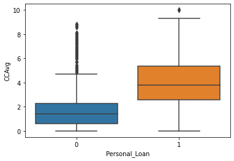

```python
for i in ['Income','Family','Education','CCAvg']:
    sns.boxplot(x='Personal_Loan', y=i,data = df)
    plt.show()
```

Key takeaways for marketing team :

1. To target people with higher income, with at least around 130
2. To target people with another family member (married couples, with or without children)
3. To target people with the education level as a graduate or advanced/professional
4. To target people with higher level of average credit card spending/month, at least 2.5 or above